# Initial income distribution

Use `sample_size_tb` to compare log income distributions and mean excess functions across 2014–2020 for observations at age 25. Corresponding to sales at firm age five in the firm analysis, income at age 25 is treated as initial size in the income analysis. Initial income is income at age 25 rather than at age 20, when data generation begins.

## 1 Data preparation

```r
library(tidyverse)
library(pins)
# Specify relative paths for the board, figure output directory, and plotting theme.
board <- board_folder("../income_board_replicate")
graph_dir <- "graph"
dir.create(graph_dir, recursive = TRUE, showWarnings = FALSE)
source("theme_ipsum_like.R")
theme_set(theme_ipsum())
```

Load income data and calculate age `age` as observation year `year` minus the birth year in the first four characters of `birth_date`. Retain observations at age 25 with positive income `main_var` in `init_size_tb`.

```r
library(scattermore)

sample_size_tb <- board |> pin_read("sample_size_tb") |>
  mutate(age = as.numeric(year) - as.numeric(str_sub(birth_date, 1, 4)))

init_size_tb <- sample_size_tb |> filter(age == 25, main_var > 0)
```

## 2 Density estimation

Compare income distributions at age 25 across 2014–2020, using colors to distinguish years. Estimate the density of base-10 log income $\log_{10}(\mathrm{main\_var})$, displaying income amounts on a logarithmic horizontal scale and density on a logarithmic vertical scale. Display income in yen from $10^3$ to $10^9$ and density from $10^{-4}$ to $1$.

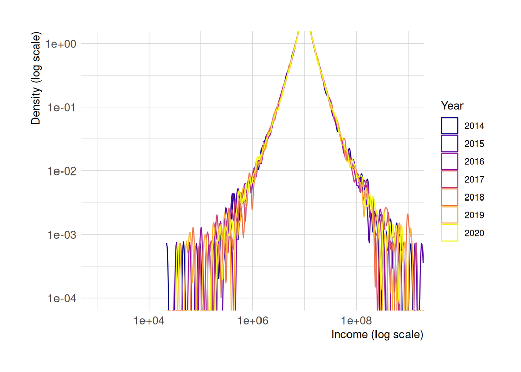

```r
init_size_tb |>
ggplot() +
  geom_density(aes(main_var, color = year)) +
  scale_color_viridis_d(option = "C") +
  scale_x_log10() + scale_y_log10() +
  coord_cartesian(xlim = c(10^3, 10^9), ylim = c(10^{-4}, 10^0)) +
  labs(
      x = "Income (log scale)",
      y = "Density (log scale)",
      color = "Year",
  )
ggsave(filename = "init_size_diff_birth_age_25_income.png", path = graph_dir)
```

## 3 Mean Excess Function

Let $L_{(i)}$ denote natural log income sorted in descending order. The calculation is as follows.

$$m_{\text{excess},i} = \frac{1}{i-1}\sum_{j=1}^{i-1}L_{(j)} - L_{(i)}, \qquad i\geq2.$$

Use the natural log income threshold on the horizontal axis, displaying values from $\log(10^{6.5})$ to $\log(10^8)$ and a vertical range of 0–1. Include observations outside the displayed range when calculating cumulative means.

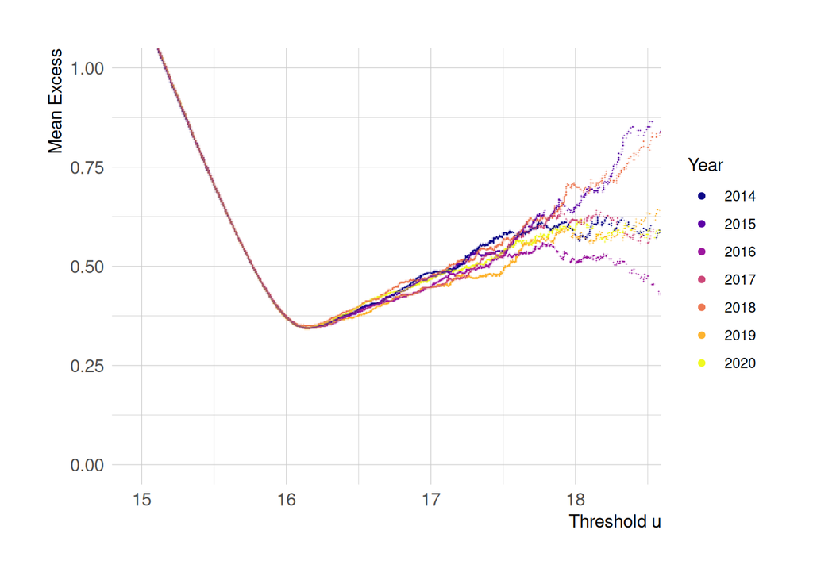

```r
init_size_tb |>
  mutate(log_main_var = log(main_var)) |>
    arrange(desc(main_var)) |>
    group_by(year) |>
    mutate(m_excess = lag(cummean(log_main_var)) - log_main_var) |>
  ggplot(aes(log_main_var, m_excess, color = year)) +
    geom_scattermore(pointsize = 1.2) +
    scale_color_viridis_d(option = "C") +
  coord_cartesian(
    xlim = c(log(10^{6.5}), log(10^8)),
    ylim = c(0, 1.0)
  ) +
  labs(
    x = "Threshold u",
    y = "Mean Excess",
    color = "Year"
  )
ggsave(filename = "mean_excess_init_size_age_25_income.png", path = graph_dir)
```